# Offline run with a shadow CAT design

The following code sets up a shadow CAT design (i.e., a CAT where a number of constraints must be satistified throughout the test adminstration). This uses integer programming methods to find the most optimal solution given a (potentially large) number of constraints. The following is a relatively simple in its inception, but demonstrates the generality of the setup and the use of the `test_properties` input.

```r
library('mirtCAT')
set.seed(1)
bank <- 300 #bank size
N <- 500 #calibration sample size

a <- rlnorm(bank, .2,.3)
d <- rnorm(bank)
pars <- data.frame(a1=a, d=d)
mod <- generate.mirt_object(pars, itemtype = '2PL')
head(coef(mod, simplify=TRUE)$items)
```

```
##           a1      d g u
## Item.1 1.012  0.894 0 1
## Item.2 1.291 -1.047 0 1
## Item.3 0.951  1.971 0 1
## Item.4 1.971 -0.384 0 1
## Item.5 1.348  1.654 0 1
## Item.6 0.955  1.512 0 1
```

This next section defines a number of test-level properties, such as

1. The type of item response stimuli (e.g., true-false, multiple-choice, fill-in-the-blank, etc),
2. The content category (e.g., addition or subtraction), and
3. Number of words in each item stem

```r
## generate random response pattern
set.seed(1)
pattern <- generate_pattern(mod, Theta = matrix(-2:2))
pattern[, 1:6]
```

```
##      [,1] [,2] [,3] [,4] [,5] [,6]
## [1,]    0    0    0    0    1    0
## [2,]    0    1    0    0    0    0
## [3,]    1    0    1    1    1    1
## [4,]    1    1    1    1    1    1
## [5,]    1    0    1    1    1    1
```

```r
test_properties <- data.frame(stimuli=rep(c('TF', 'MC', 'fill'), each=bank/3),
                              content=rep(c('add', 'sub'), times=150),
                              words=sample(10:30, bank, TRUE))
head(test_properties)
```

```
##   stimuli content words
## 1      TF     add    11
## 2      TF     sub    28
## 3      TF     add    14
## 4      TF     sub    21
## 5      TF     add    12
## 6      TF     sub    18
```

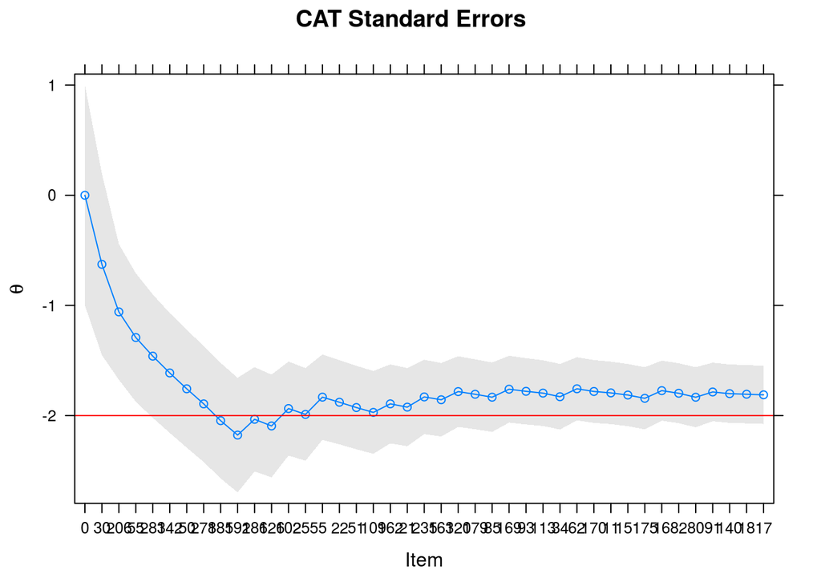

```r
# constraint generating function
constr_fun <- function(person, test, design){
  nitems <- extract.mirt(test@mo, 'nitems')
  tp <- design@test_properties

  lhs <- matrix(0, 9, nitems)
  lhs[1,] <- 1
  lhs[2,tp$stimuli == 'fill'] <- 1
  lhs[3,tp$stimuli == 'fill'] <- 1
  lhs[4, c(5, 6)] <- 1
  lhs[5, c(10,11)] <- 1
  lhs[6, c(17,18)] <- 1
  lhs[7, 15] <- 1
  lhs[8, tp$content == 'add'] <- 1
  lhs[8, tp$content == 'sub'] <- -1
  lhs[9, ] <- tp$words

  # relationship direction
  dirs <- c("==", ">=", '<=', '==', '==', '==', '==', '==', '<=')

  #right hand side
  rhs <- c(40, 3, 5, 1, 1, 2, 0, 0, 40*20)

  #all together
  constraints <- data.frame(lhs, dirs, rhs)
  constraints
}

# next item selection function
customNextItem <- function(person, design, test){
    objective <- computeCriteria(person=person, design=design, test=test,
                                 criteria = 'MI')
    item <- findNextItem(person=person, design=design, test=test,
                         objective=objective)
    item
}

result <- mirtCAT(mo=mod, start_item = 30, local_pattern = pattern,
                  design = list(customNextItem=customNextItem,
                              constr_fun=constr_fun,
                              test_properties=test_properties,
                              min_SEM=0))
plot(result[[1]])
```

```r
(items <- summary(result[[1]])$items_answered)
```

```
##  [1]  30 206  55 283 142  50 278 185 192 186 126 102 255   5  22  51 109
## [18] 162  21 235 163 120 179  85 169  93 113  34  62 170  11 151 175  16
## [35]  82  80  91 140  18  17
```

```r
head(test_properties[items, ]) #items answered
```

```
##     stimuli content words
## 30       TF     sub    30
## 206    fill     sub    13
## 55       TF     add    21
## 283    fill     add    18
## 142      MC     sub    25
## 50       TF     sub    23
```

```r
table(test_properties[items, 1:2])
```

```
##        content
## stimuli add sub
##    fill   3   2
##    MC     8   9
##    TF     9   9
```

```r
colSums(table(test_properties[items, 1:2]))
```

```
## add sub
##  20  20
```

```r
mean(test_properties[items, 3])
```

```
## [1] 20
```

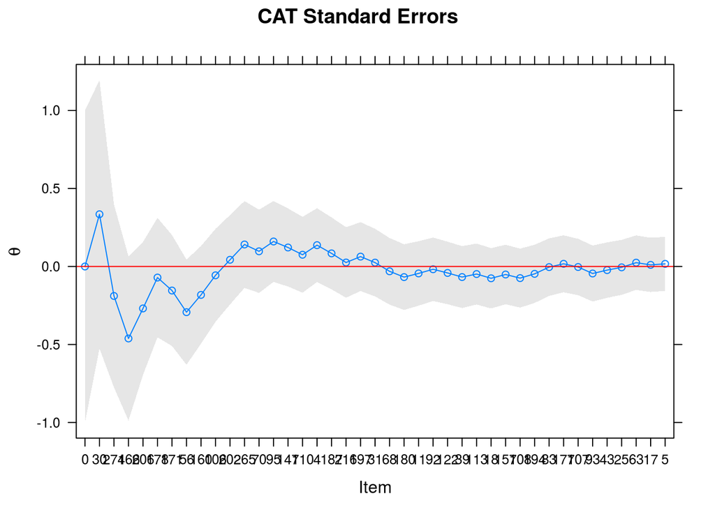

```r
plot(result[[3]])
```

```r
(items <- summary(result[[3]])$items_answered)
```

```
##  [1]  30 274 166 206 178 171  56 160 106 202 265  70  95 147 110   4 187
## [18] 216 197  31  68 180  11  92 122  39 113  18 157 108 194  83 177 107
## [35]  93  43  25  63  17   5
```

```r
head(test_properties[items, ]) #items answered
```

```
##     stimuli content words
## 30       TF     sub    30
## 274    fill     sub    14
## 166      MC     sub    30
## 206    fill     sub    13
## 178      MC     sub    28
## 171      MC     add    28
```

```r
table(test_properties[items, 1:2])
```

```
##        content
## stimuli add sub
##    fill   1   4
##    MC     8   9
##    TF    11   7
```

```r
colSums(table(test_properties[items, 1:2]))
```

```
## add sub
##  20  20
```

```r
mean(test_properties[items, 3])
```

```
## [1] 19.175
```

Notice that each of these response patterns satisfy all of the proposed constraints. This is the general benifit of shadow CATs: optimal item selection (according to the item selection critiera) while simultaneously considering a wide and complicated set of item-design constraints.